# Лабораторной работы №8

Дисциплина “Операционные системы”

Обрезкова А.В.

Российский университет дружбы народов, Москва, Россия

ФФМиЕН

1 апреля 2023

# Информация

## Докладчик

- Обрезкова Анастасия Владимировна
- студентка направления “Математика и механика”
- Российский университет дружбы народов
- 1132226505@pfur.ru

# Вводная часть

## Цель работы

Познакомиться с операционной системой Linux. Получить практические навыки работы с редактором vi, установленным по умолчанию практически во всех дистрибутивах.

# Основная часть

## Создание нового файла с использованием vi

- Создала каталог с именем ~/work/os/lab06 с помощью команды “mkdir -p ~/work/os/lab06”
- Перешла во вновь созданный каталог.

## Создание нового файла с использованием vi

- Вызвала vi и создала файл hello.sh

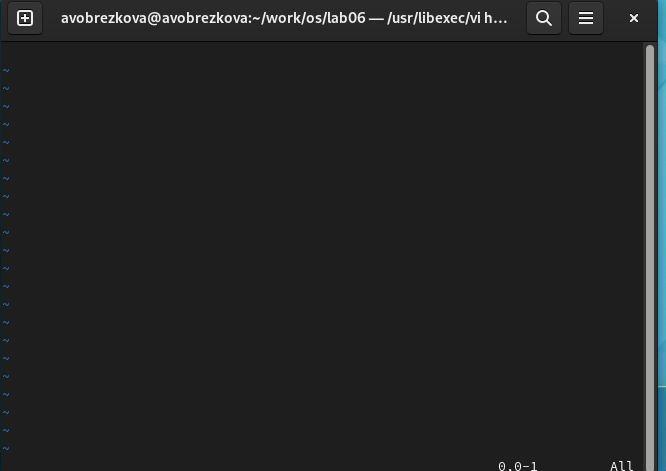

## Создание нового файла с использованием vi

- Нажала клавишу “i” и ввела следующий текст

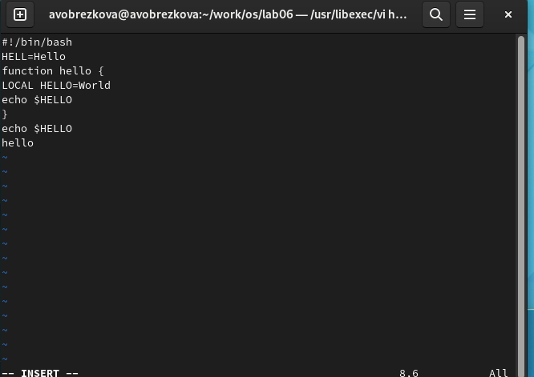

## Создание нового файла с использованием vi

- Нажала клавишу “Esc” для перехода в командный режим после завершения ввода текста.

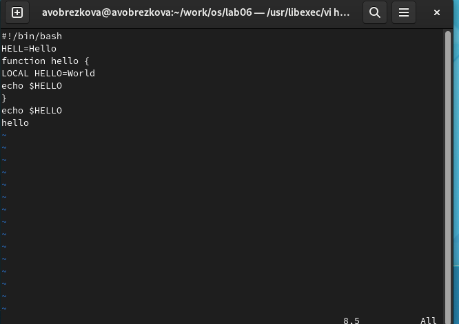

## Создание нового файла с использованием vi

- Нажала “:” для перехода в режим последней строки и внизу моего экрана появилось приглашение в виде двоеточия.

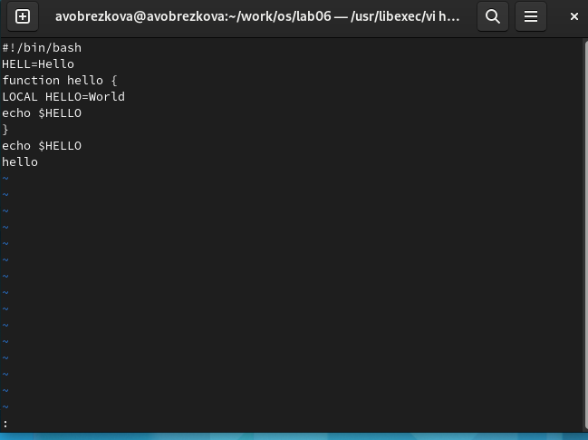

## Создание нового файла с использованием vi

- Нажала “w” (записать) и “q” (выйти), а затем нажала клавишу “Enter” для сохранения моего текста и завершения работы.

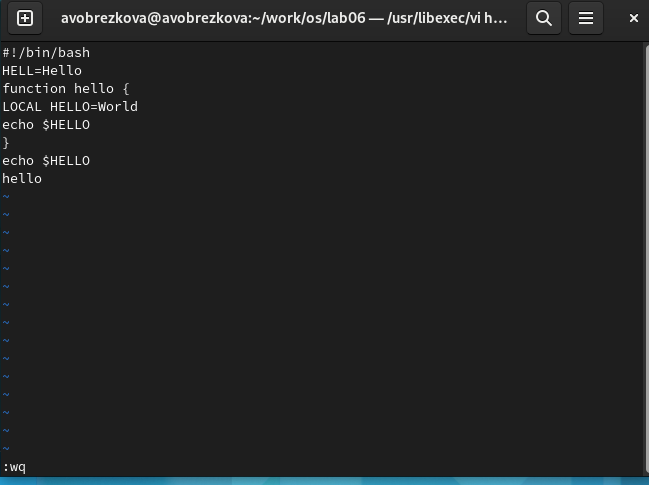

## Создание нового файла с использованием vi

- Сделала файл исполняемым.

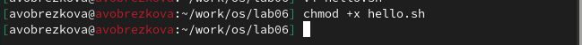

## Редактирование существующего файла

- Вызвала vi на редактирование файла с помощью команды “vi ~/work/os/lab06/hello.sh”

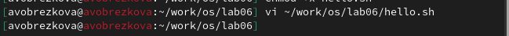

## Редактирование существующего файла

- Установила курсор в конец слова HELL второй строки.

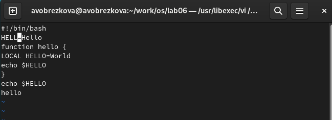

## Редактирование существующего файла

- Перешла в режим вставки и заменила на HELLO. Нажала “Esc” для возврата в командный режим.

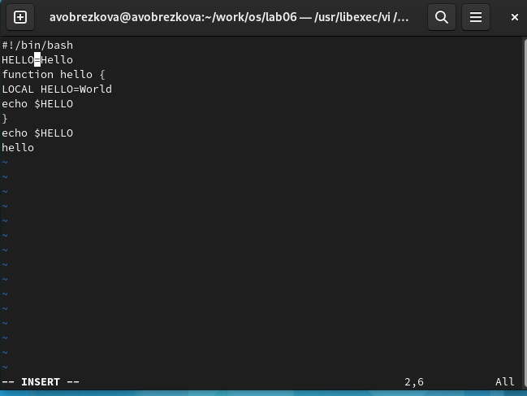

## Редактирование существующего файла

- Установила курсор на четвертую строку и стерла слово LOCAL.

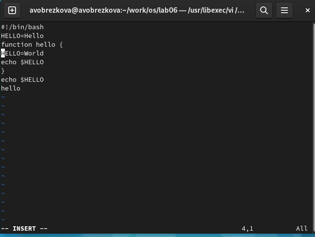

## Редактирование существующего файла

- Перешла в режим вставки и набрала следующий текст: “local”, нажала “Esc” для возврата в командный режим.

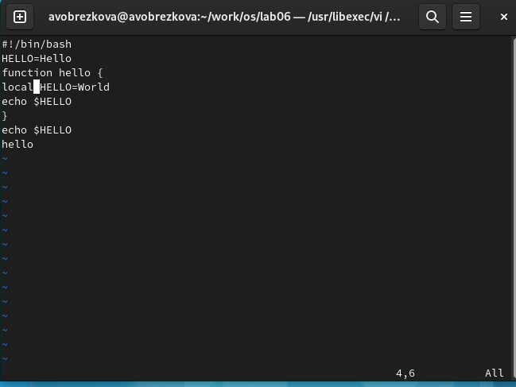

## Редактирование существующего файла

- Установила курсор на последней строке файла. Вставилп после неё строку, содержащую следующий текст: “echo $HELLO”.

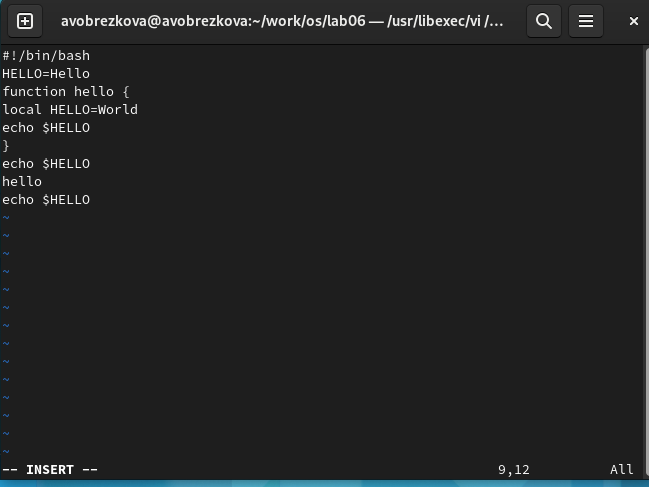

## Редактирование существующего файла

- Нажала “Esc” для перехода в командный режим.

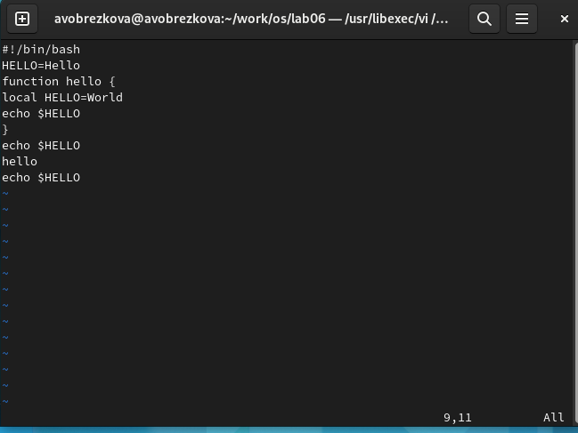

## Редактирование существующего файла

- Удалила последнюю строку с помощью комбинации клавиш, используя сочетание “d”, “d”.

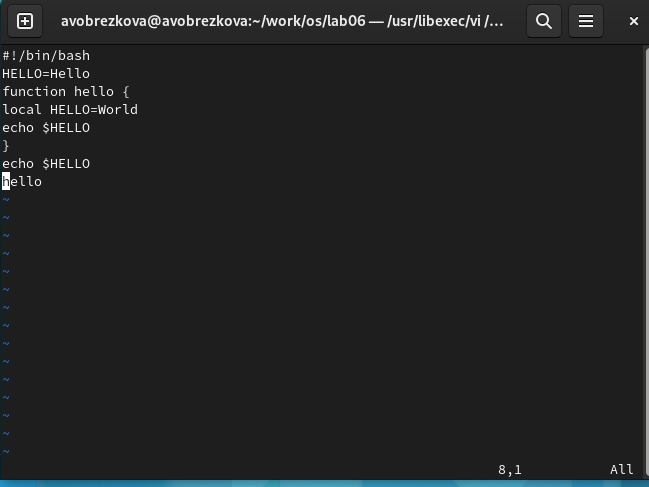

## Редактирование существующего файла

- Ввела команду отмены изменений “u” для отмены последней команды.

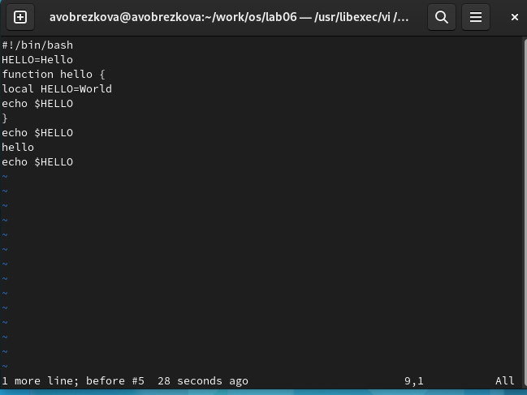

## Редактирование существующего файла

- Ввела символ “:” для перехода в режим последней строки. Записала произведённые изменения, сохранила и вышла из vi..

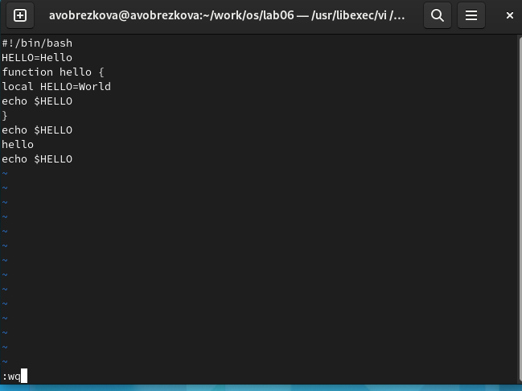

# Заключение

## Вывод

В ходе выполнения лабораторной работы я познакомилась с операционной системой Linux. Получила практические навыки работы с редактором vi, установленным по умолчанию практически во всех дистрибутивах.